# Analytical Validation Report: Germline SNV/Indel Panel

GermlineQC v1.0.0 · GIAB HG001 / HG002 · chr20 panel (JAG1, GNAS loci)

## 1. Summary

The pipeline **meets 6 of 7** pre-defined acceptance criteria. Not met: Repeatability (min pairwise concordance). See section 6 for the investigation and corrective action. All samples are reference material from the Genome in a Bottle consortium, sequenced on Illumina HiSeq 2500 (2 x 148 bp) and benchmarked against the GIAB v4.2.1 truth sets inside GIAB high-confidence regions that overlap the panel.

[output not shown]

## 2. Study design

| Study | Question answered | Samples |
| --- | --- | --- |
| Accuracy | Does the assay call the right variants? | every HG001 run at 30x + HG002 at 30x |
| Repeatability | Same library, same instrument, short time window: do replicates agree? | 3 disjoint read subsets |
| Reproducibility | Different sequencing runs, instruments and dates (Dec 2013 to Apr 2014) | 4 independent runs |
| Depth titration | Lowest depth at which SNV sensitivity stays above target (limit of detection) | 5x to 100x |

| Sample | Study | Material | Source | Nominal depth | Observed depth | Target >= 20x | QC |
| --- | --- | --- | --- | --- | --- | --- | --- |
| HG001_repeat_1 | repeatability | HG001 | batch_2014-01_HISEQ1 | 30.0 | 28.2 | 90.0% | FAIL |
| HG001_repeat_2 | repeatability | HG001 | batch_2014-01_HISEQ1 | 30.0 | 28.2 | 89.9% | FAIL |
| HG001_repeat_3 | repeatability | HG001 | batch_2014-01_HISEQ1 | 30.0 | 28.3 | 90.1% | FAIL |
| HG001_run_1 | reproducibility | HG001 | run_2013-12-19_D00360 | 30.1 | 28.6 | 90.8% | FAIL |
| HG001_run_2 | reproducibility | HG001 | run_2013-12-23_D00360 | 29.9 | 28.4 | 91.0% | FAIL |
| HG001_run_3 | reproducibility | HG001 | run_2014-03-13_HISEQ1 | 30.0 | 28.3 | 90.6% | FAIL |
| HG001_run_4 | reproducibility | HG001 | run_2014-04-07_HISEQ1 | 30.0 | 28.3 | 91.2% | FAIL |
| HG001_depth_005x | titration | HG001 | all runs pooled | 5.0 | 4.7 | 0.0% | FAIL |
| HG001_depth_010x | titration | HG001 | all runs pooled | 10.0 | 9.4 | 0.4% | FAIL |
| HG001_depth_015x | titration | HG001 | all runs pooled | 15.0 | 14.2 | 11.4% | FAIL |
| HG001_depth_020x | titration | HG001 | all runs pooled | 20.1 | 18.9 | 44.1% | FAIL |
| HG001_depth_030x | titration | HG001 | all runs pooled | 30.0 | 28.3 | 90.5% | FAIL |
| HG001_depth_050x | titration | HG001 | all runs pooled | 49.9 | 47.1 | 99.7% | PASS |
| HG001_depth_100x | titration | HG001 | all runs pooled | 100.0 | 94.4 | 100.0% | PASS |
| HG002_acc | accuracy | HG002 | NHGRI 300x | 30.0 | 28.4 | 90.0% | FAIL |

## 3. Accuracy

Sensitivity = TP / (TP + FN), PPV = TP / (TP + FP), both with 95% Wilson score intervals. Genotype must match for a call to count as a true positive (RTG vcfeval, haplotype-aware comparison).

| Sample | Type | TP | FP | FN | Sensitivity | PPV | F1 |
| --- | --- | --- | --- | --- | --- | --- | --- |
| HG001_repeat_1 | SNV | 1796 | 2 | 13 | 99.28% (98.77%-99.58%) | 99.89% (99.60%-99.97%) | 0.9958 |
| HG001_repeat_1 | INDEL | 327 | 0 | 0 | 100.00% (98.84%-100.00%) | 100.00% (98.89%-100.00%) | 1.0000 |
| HG001_repeat_2 | SNV | 1797 | 0 | 12 | 99.34% (98.84%-99.62%) | 100.00% (99.79%-100.00%) | 0.9967 |
| HG001_repeat_2 | INDEL | 325 | 1 | 2 | 99.39% (97.80%-99.83%) | 99.71% (98.35%-99.95%) | 0.9955 |
| HG001_repeat_3 | SNV | 1791 | 6 | 18 | 99.00% (98.43%-99.37%) | 99.67% (99.27%-99.85%) | 0.9933 |
| HG001_repeat_3 | INDEL | 322 | 2 | 5 | 98.47% (96.47%-99.35%) | 99.41% (97.86%-99.84%) | 0.9894 |
| HG001_run_1 | SNV | 1803 | 0 | 6 | 99.67% (99.28%-99.85%) | 100.00% (99.79%-100.00%) | 0.9983 |
| HG001_run_1 | INDEL | 324 | 2 | 3 | 99.08% (97.34%-99.69%) | 99.41% (97.88%-99.84%) | 0.9925 |
| HG001_run_2 | SNV | 1795 | 5 | 14 | 99.23% (98.71%-99.54%) | 99.72% (99.35%-99.88%) | 0.9947 |
| HG001_run_2 | INDEL | 323 | 2 | 4 | 98.78% (96.90%-99.52%) | 99.41% (97.87%-99.84%) | 0.9909 |
| HG001_run_3 | SNV | 1794 | 1 | 15 | 99.17% (98.64%-99.50%) | 99.94% (99.69%-99.99%) | 0.9956 |
| HG001_run_3 | INDEL | 323 | 1 | 4 | 98.78% (96.90%-99.52%) | 99.70% (98.34%-99.95%) | 0.9924 |
| HG001_run_4 | SNV | 1794 | 0 | 15 | 99.17% (98.64%-99.50%) | 100.00% (99.79%-100.00%) | 0.9958 |
| HG001_run_4 | INDEL | 324 | 0 | 3 | 99.08% (97.34%-99.69%) | 100.00% (98.88%-100.00%) | 0.9954 |
| HG002_acc | SNV | 1814 | 2 | 16 | 99.13% (98.58%-99.46%) | 99.89% (99.60%-99.97%) | 0.9951 |
| HG002_acc | INDEL | 308 | 2 | 8 | 97.47% (95.08%-98.71%) | 99.39% (97.80%-99.83%) | 0.9842 |

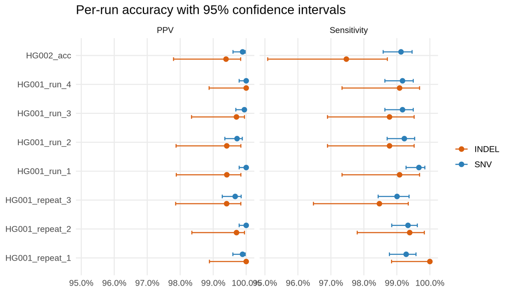

### Specificity

Specificity is reported per base: every high-confidence reference position that is not a truth variant counts as a negative, and any PASS call there is a false positive. Because nearly all positions are reference, this figure is always very close to 100%. PPV is the more informative measure of false-positive burden, so both are reported.

| Sample | Bases evaluated | True negatives | FP | Specificity |
| --- | --- | --- | --- | --- |
| HG001_depth_005x | 1,452,464 | 1,450,214 | 114 | 99.99210% (99.99060-99.99350) |
| HG001_depth_010x | 1,452,464 | 1,450,296 | 32 | 99.99780% (99.99690-99.99840) |
| HG001_depth_015x | 1,452,464 | 1,450,317 | 11 | 99.99920% (99.99860-99.99960) |
| HG001_depth_020x | 1,452,464 | 1,450,315 | 13 | 99.99910% (99.99850-99.99950) |
| HG001_depth_030x | 1,452,464 | 1,450,326 | 2 | 99.99990% (99.99950-100.00000) |
| HG001_depth_050x | 1,452,464 | 1,450,328 | 0 | 100.00000% (99.99970-100.00000) |
| HG001_depth_100x | 1,452,464 | 1,450,327 | 1 | 99.99990% (99.99960-100.00000) |
| HG001_repeat_1 | 1,452,464 | 1,450,326 | 2 | 99.99990% (99.99950-100.00000) |
| HG001_repeat_2 | 1,452,464 | 1,450,327 | 1 | 99.99990% (99.99960-100.00000) |
| HG001_repeat_3 | 1,452,464 | 1,450,320 | 8 | 99.99940% (99.99890-99.99970) |
| HG001_run_1 | 1,452,464 | 1,450,326 | 2 | 99.99990% (99.99950-100.00000) |
| HG001_run_2 | 1,452,464 | 1,450,321 | 7 | 99.99950% (99.99900-99.99980) |
| HG001_run_3 | 1,452,464 | 1,450,326 | 2 | 99.99990% (99.99950-100.00000) |
| HG001_run_4 | 1,452,464 | 1,450,328 | 0 | 100.00000% (99.99970-100.00000) |
| HG002_acc | 1,464,134 | 1,461,984 | 4 | 99.99970% (99.99930-99.99990) |

## 4. Precision: repeatability and reproducibility

Concordance = calls with identical genotype in both replicates / all distinct calls in either replicate (PASS calls inside the evaluation region).

| Study | Replicate A | Replicate B | Shared | Only A | Only B | GT match | Concordance |
| --- | --- | --- | --- | --- | --- | --- | --- |
| repeatability | HG001_repeat_1 | HG001_repeat_2 | 2126 | 15 | 13 | 2125 | 98.65% (98.07%-99.06%) |
| repeatability | HG001_repeat_1 | HG001_repeat_3 | 2117 | 24 | 19 | 2115 | 97.92% (97.22%-98.44%) |
| repeatability | HG001_repeat_2 | HG001_repeat_3 | 2118 | 21 | 18 | 2115 | 98.05% (97.38%-98.56%) |
| reproducibility | HG001_run_1 | HG001_run_2 | 2128 | 17 | 13 | 2125 | 98.47% (97.86%-98.91%) |
| reproducibility | HG001_run_1 | HG001_run_3 | 2126 | 19 | 9 | 2124 | 98.61% (98.02%-99.02%) |
| reproducibility | HG001_run_1 | HG001_run_4 | 2127 | 18 | 7 | 2126 | 98.79% (98.24%-99.17%) |
| reproducibility | HG001_run_2 | HG001_run_3 | 2117 | 24 | 18 | 2116 | 98.01% (97.33%-98.52%) |
| reproducibility | HG001_run_2 | HG001_run_4 | 2121 | 20 | 13 | 2120 | 98.42% (97.80%-98.87%) |
| reproducibility | HG001_run_3 | HG001_run_4 | 2116 | 19 | 18 | 2116 | 98.28% (97.64%-98.75%) |

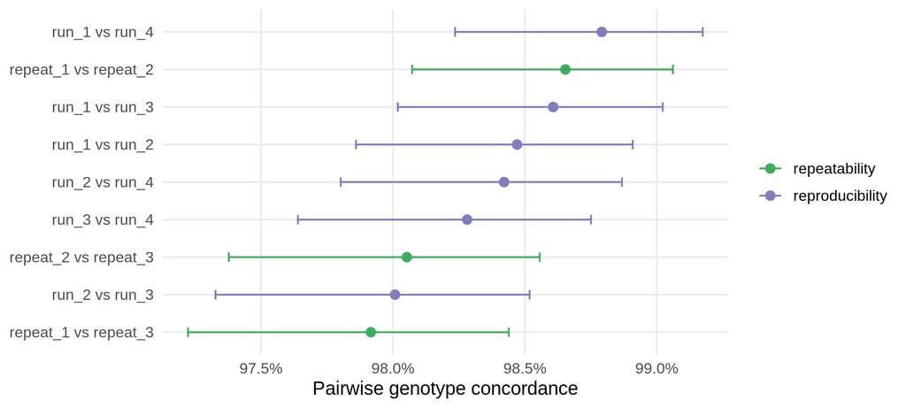

### Discordant calls

| Study | Calls | N | Median depth | Depth < 15 | Depth < 20 | GQ < 20 |
| --- | --- | --- | --- | --- | --- | --- |
| repeatability | concordant | 6355 | 27 | 2.9% | 13.2% | 0.1% |
| repeatability | discordant | 122 | 23 | 22.1% | 33.6% | 4.9% |
| reproducibility | concordant | 12727 | 28 | 2.6% | 12.1% | 0.1% |
| reproducibility | discordant | 211 | 22 | 19.4% | 40.3% | 4.3% |

## 5. Depth titration (limit of detection)

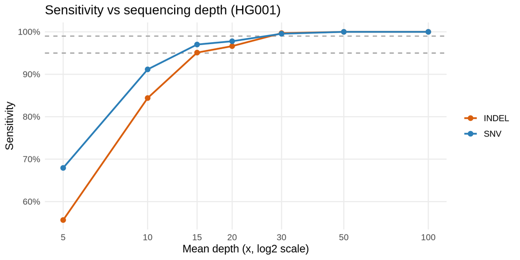

| Nominal depth | Observed depth | SNV sens | SNV PPV | Indel sens | Indel PPV |
| --- | --- | --- | --- | --- | --- |
| 5 | 4.7 | 67.94% | 93.46% | 55.66% | 86.79% |
| 10 | 9.4 | 91.16% | 98.86% | 84.40% | 95.62% |
| 15 | 14.2 | 97.01% | 99.60% | 95.11% | 98.78% |
| 20 | 18.9 | 97.79% | 99.72% | 96.64% | 97.62% |
| 30 | 28.3 | 99.56% | 99.94% | 99.69% | 99.71% |
| 50 | 47.1 | 100.00% | 100.00% | 100.00% | 100.00% |
| 100 | 94.4 | 100.00% | 100.00% | 100.00% | 99.71% |

## 6. Findings and corrective action

**Finding 1: repeatability below target.** The lowest pairwise concordance between same-batch replicates was 97.92% against a target of 99%. Discordant calls are enriched for low read depth: 22% of discordant calls have fewer than 15 reads, compared with 3% of concordant calls. This points to random sampling of reads at ~30x rather than a systematic pipeline fault (the same replicates reach 99.00% or better SNV sensitivity).

**Finding 2: the 30x replicates do not meet the per-sample coverage gate.** Only 89.9% to 91.2% of target bases reach 20x, below the 95% requirement. In the titration series the gate is first met at 49.9x nominal depth (47.1x observed). SNV sensitivity reaches 99% from 30x.

**Corrective action.** The acceptance criteria are not changed after the fact. Instead:

## 7. Limitations

- The panel covers 1.5 Mb of chr20, so indel counts are small and their confidence intervals are wide. A clinical validation would add more loci and more reference samples (for example HG003 to HG007) to reach the sample sizes in the validation plan.
- Repeatability and reproducibility replicates are read subsets from GIAB sequencing runs rather than separate library preparations, so they capture sequencing and analysis variation but not wet-lab variation.
- Only regions that GIAB marks as high-confidence are scored. Difficult regions (segmental duplications, long homopolymers) are outside the benchmark and need separate handling, for example with orthogonal confirmation.
- Copy-number variants, structural variants and mosaic variants are out of scope.

Generated by `reports/validation_report.Rmd` from the tables in `results_validation/validation/tables`.